# Homework 3

Benjamin Ridenhour

22-Sep-23

### Entering Data and Modifying Them

The data in the book are as follows:

```r
fish <- data.frame("l" = c(14.5, 12.5, 17.25, 14.5, 12.625, 17.75, 14.125, 12.625),
                   "g" = c(9.75, 8.375, 11.0, 9.75, 8.5, 12.5, 9.0, 8.5),
                   "W" = c(27, 17, 41, 26, 17, 49, 23, 16))
head(fish)
```

|  | l | g | W |
| --- | --- | --- | --- |
| 1 | 14.500 | 9.750 | 27 |
| 2 | 12.500 | 8.375 | 17 |
| 3 | 17.250 | 11.000 | 41 |
| 4 | 14.500 | 9.750 | 26 |
| 5 | 12.625 | 8.500 | 17 |
| 6 | 17.750 | 12.500 | 49 |

I asked you to make two modifications to the data. The first task was to add some error to the data using `rnorm`. This is easily accomplished using:

```r
set.seed(68459)
fish_noisy <- data.frame(apply(fish, c(1,2), function(x) rnorm(1,x)))
head(fish_noisy)
```

|  | l | g | W |
| --- | --- | --- | --- |
| 1 | 13.09223 | 10.049867 | 27.16572 |
| 2 | 12.11434 | 9.618248 | 16.71103 |
| 3 | 16.30117 | 11.791402 | 43.38272 |
| 4 | 13.69022 | 10.781787 | 25.12849 |
| 5 | 12.34343 | 8.837926 | 17.29332 |
| 6 | 18.22708 | 11.470993 | 50.15631 |

Note the second argument in `apply` where I specify `c(1,2)`. This tells `apply` that I want to apply my function to each element of the data frame. The call to `rnorm` indicates that I want 1 random with mean $x$; I did not specify a SD, therefore it uses the default of 1.

The next step of the homework to create a third data set with outliers in the weight variable. These aren’t terribly specific instructions; we need to choose how many observations to alter the weight and by how much. The coefficient of variation is defined as the variance of a variable divided by its mean. For weight, the CV is 5.720806. For 3 of the data points, let’s add something within $\pm2$CV.

```r
set.seed(15697)
fish_outlier <- fish_noisy
nChanges <- 3
changeMe  <- sample(1:nrow(fish_outlier), nChanges)
CV <- var(fish_outlier$W)/mean(fish_outlier$W)
fish_outlier$W[changeMe] <- fish_outlier$W[changeMe] + rnorm(nChanges,CV)*sample(c(-1,1),nChanges,replace=T)
fish$W - fish_outlier$W #compare our final W to the original W
```

```
## [1] -0.1657152  0.2889739 -7.9644293  0.8715099  5.0217118 -1.1563084 -1.5374328
## [8] -6.9091701
```

Okay, our data look good and ready for our models.

### Optimization with Different Criteria

Okay, first we need to grab the code from the lecture that has the different criteria.

```r
chebyshev <- function(y, yhat) max(abs(y - yhat))
meanAD <- function(y, yhat) mean(abs(y - yhat))
medianAD <- function(y, yhat) median(abs(y - yhat))
leastSq <- function(y, yhat) mean(abs(y - yhat)^2)
llnorm <- function(y, yhat) sum(dnorm(y, yhat, log = T))
```

We also need the two different models, $W = k l^3$ and $W = k l g^2$. Let’s write objective functions for these two models:

```r
## for W = k l ^3
objOne <- function(k, data, dist = "chebyshev"){
  with(data,{
    W_hat <- k*l^3 #calculate the value of the first model for some parameter
    eval(call(dist, W, W_hat)) #use the distance function specified
  })
}

## for W = k l g ^2
objTwo <- function(k, data, dist = "chebyshev"){
  with(data,{
    W_hat <- k*l*g^2 #calculate the value of the first model for some parameter
    eval(call(dist, W, W_hat)) #use the distance function specified
  })
}

###Try it out
objOne(0.5,fish)
```

```
## [1] 2747.18
```

```r
objTwo(0.5,fish)
```

```
## [1] 1337.719
```

It looks like the objective functions are ready for use in optimization. The last thing we need for optimization is a guess at the parameter value. Let’s just assume that the average solution for $W$ is a good starting point.

```r
#Model one guesses
guess_1 <- with(fish, mean(W / l^3))
guess_1_n <- with(fish_noisy, mean(W / l^3))
guess_1_o <- with(fish_outlier, mean(W / l^3))

#Model two guesses
guess_2 <- with(fish, mean(W / (l*g^2)))
guess_2_n <- with(fish_noisy, mean(W / (l*g^2)))
guess_2_o <- with(fish_outlier, mean(W / (l*g^2)))

c(guess_1,guess_1_n,guess_1_o)
```

```
## [1] 0.008424862 0.009415505 0.009465100
```

```r
c(guess_2,guess_2_n,guess_2_o)
```

```
## [1] 0.01892890 0.01802916 0.01846227
```

It looks like the guesses don’t vary much between the data sets, so we can just use one of the guesses for each model ($\sim 0.009$ and $\sim 0.018$ for models 1 and 2, respectively). We can now perform optimization using the five criteria and the three data sets.

```r
results <- data.frame()
critList <- c("chebyshev","meanAD","medianAD","leastSq","llnorm")
dataList <- c("fish","fish_noisy","fish_outlier")
for(i in critList){
  for(j in dataList){
    clist <- if(i == "llnorm") list(fnscale = -1) else list()
    newResult <- data.frame(optim(guess_1, objOne, data = get(j), dist = i, control = clist)[c("par","value","convergence")])
    newResult$Criteria <- i
    newResult$Data <- j
    results <- rbind(results, newResult)
  }
}
```

[output not shown]

```r
results
```

| par | value | convergence | Criteria | Data |
| --- | --- | --- | --- | --- |
| 0.008391364 | 2.072478 | 0 | chebyshev | fish |
| 0.008432437 | 8.242546 | 0 | chebyshev | fish_noisy |
| 0.009542590 | 7.628999 | 0 | chebyshev | fish_outlier |
| 0.008528435 | 0.972877 | 0 | meanAD | fish |
| 0.009399487 | 3.913939 | 0 | meanAD | fish_noisy |
| 0.009399487 | 4.549453 | 0 | meanAD | fish_outlier |
| 0.008688139 | 0.500000 | 0 | medianAD | fish |
| 0.010207819 | 1.670563 | 0 | medianAD | fish_noisy |
| 0.008623113 | 3.620832 | 0 | medianAD | fish_outlier |
| 0.008436740 | 1.521043 | 0 | leastSq | fish |

[output cut: 5 more lines]

```r
### repeat for model 2

results2 <- data.frame()
for(i in critList){
  for(j in dataList){
    clist <- if(i == "llnorm") list(fnscale = -1) else list()
    newResult <- data.frame(optim(guess_2, objTwo, data = get(j), dist = i, control = clist)[c("par","value","convergence")])
    newResult$Criteria <- i
    newResult$Data <- j
    results2 <- rbind(results2, newResult)
  }
}
```

[output not shown]

```r
results2
```

| par | value | convergence | Criteria | Data |
| --- | --- | --- | --- | --- |
| 0.01851590 | 2.3526893 | 0 | chebyshev | fish |
| 0.01886917 | 4.9007619 | 0 | chebyshev | fish_noisy |
| 0.01886421 | 6.2093066 | 0 | chebyshev | fish_outlier |
| 0.01886236 | 1.1544172 | 0 | meanAD | fish |
| 0.01914114 | 2.8099014 | 0 | meanAD | fish_noisy |
| 0.02054409 | 4.6085680 | 0 | meanAD | fish_outlier |
| 0.01933716 | 0.6464873 | 0 | medianAD | fish |
| 0.02005926 | 2.0637018 | 0 | medianAD | fish_noisy |
| 0.01794734 | 4.3795216 | 0 | medianAD | fish_outlier |
| 0.01867508 | 2.2088872 | 0 | leastSq | fish |

[output cut: 5 more lines]

The last thing you were asked to do is plot the different solutions from the different criteria. First we need to create the data to plot, then pass those data to `ggplot`.

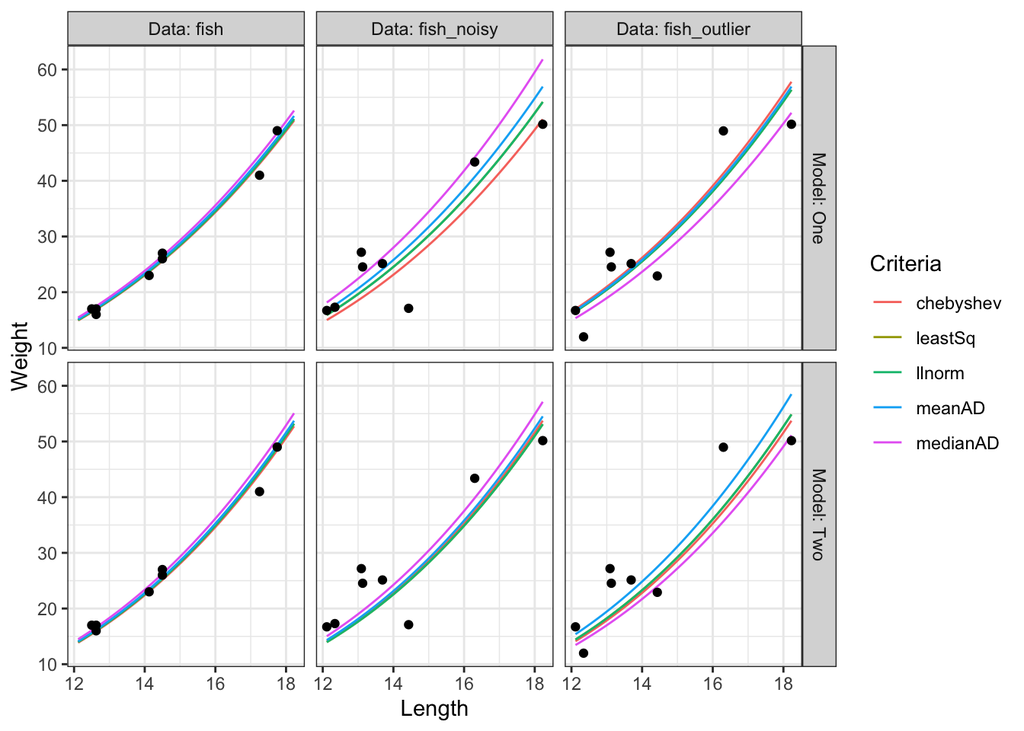

```r
modelOne <- function(l, k) k * l^3
modelTwo <- function(l, g, k) k * l * g^2

raw <- rbind(fish,fish_noisy, fish_outlier)
raw$Data <- rep(dataList, each = nrow(fish))

lVals <- seq(min(raw$l), max(raw$l), length=100)
gVals <- seq(min(raw$g), max(raw$g), length=100)


plotData <- data.frame()
for(i in critList){
  for(j in dataList){
    p1 <- subset(results, Data == j & Criteria == i)$par
    p2 <- subset(results2, Data == j & Criteria == i)$par
    plotData <- rbind(plotData,
                      data.frame(l=lVals, Criteria = i, Data = j,
                                 W = c(modelOne(lVals, p1), modelTwo(lVals,gVals,p2)),
                                 Model = rep(c("One","Two"), each = length(lVals)))
                      )
  }
}

library(ggplot2)
g <- ggplot(plotData, aes(x = l, y = W))
g + geom_line(aes(color=Criteria)) + geom_point(data = raw) +
  facet_grid(rows = vars(Model), cols= vars(Data), labeller = label_both) +
  theme_bw() + xlab("Length") + ylab("Weight")
```

### Testing Different `optim` Algorithms

The final part of the homework was to compare the various methods available to `optim` or `minimize` to perform the optimization. You were asked to make a table of the results.

```r
algos <- c("Nelder-Mead", "BFGS", "CG", "L-BFGS-B", "SANN","Brent")

results3 <- data.frame()
for(i in critList){
  for(j in dataList){
    for(k in algos){
      clist <- if(i == "llnorm") list(fnscale = -1) else list()
      newResult <- suppressWarnings(data.frame(optim(guess_1, objOne, data = get(j), dist = i,
                                    control = clist, method = k, lower = 0, upper = 1)[c("value")]))
      newResult$Criteria <- i
      newResult$Data <- j
      newResult$Algorithm <- k
      results3 <- rbind(results3, newResult)
    }
  }
}

xtabs(value ~ Criteria + Algorithm + Data, data = results3)
```

```
## , , Data = fish
##
##            Algorithm
## Criteria            BFGS        Brent           CG     L-BFGS-B  Nelder-Mead
##   chebyshev    2.2444216    2.0724845    2.2444216    2.2444216    2.2444216
##   leastSq      1.5210427    1.5210427    1.5210427    1.5210427    1.5210427
##   llnorm     -13.4356792  -13.4356792  -13.4356792  -13.4356792  -13.4356792
##   meanAD       1.0014416    0.9728772    1.0014416    1.0014416    1.0014416
##   medianAD     0.7860166    0.5000000    0.7860166    0.7860166    0.7860166
##            Algorithm
## Criteria            SANN
##   chebyshev    2.2444216
##   leastSq      1.5210427
##   llnorm     -13.4356792
##   meanAD       1.0014416
##   medianAD     0.7860166
##
## , , Data = fish_noisy
##
##            Algorithm
## Criteria            BFGS        Brent           CG     L-BFGS-B  Nelder-Mead
##   chebyshev    8.2595448    8.2425454    8.2595448    8.2595448    8.2595448
##   leastSq     25.9545905   25.9545905   25.9545905   25.9545905   25.9545905
##   llnorm    -111.1698703 -111.1698703 -111.1698703 -111.1698703 -111.1698703
##   meanAD       3.9424201    3.9139390    3.9424201    3.9424201    3.9424201
##   medianAD     1.6743069    1.6705635    1.6743069    1.6743069    1.6743069
##            Algorithm
## Criteria            SANN
##   chebyshev    8.2595448
##   leastSq     25.9545905
##   llnorm    -111.1698703
##   meanAD       3.9424201
##   medianAD     1.6743069
##
## , , Data = fish_outlier
##
##            Algorithm
## Criteria            BFGS        Brent           CG     L-BFGS-B  Nelder-Mead
##   chebyshev    8.3105649    7.6290023    8.3105649    8.3105649    8.3105649
##   leastSq     27.8116406   27.8116406   27.8116406   27.8116406   27.8116406
##   llnorm    -118.5980705 -118.5980705 -118.5980705 -118.5980705 -118.5980705
##   meanAD       4.5867898    4.5494531    4.5867898    4.5867898    4.5867898
##   medianAD     3.6575449    3.6208316    3.6575449    3.6575449    3.6575449
##            Algorithm
## Criteria            SANN
##   chebyshev    8.3105649
##   leastSq     27.8116406
##   llnorm    -118.5980705
##   meanAD       4.5867898
##   medianAD     3.6575449
```

And for model 2:

```r
### model 2

results4 <- data.frame()
for(i in critList){
  for(j in dataList){
    for(k in algos){
      clist <- if(i == "llnorm") list(fnscale = -1) else list()
      newResult <- suppressWarnings(data.frame(optim(guess_2, objTwo, data = get(j), dist = i,
                                    control = clist, method = k, lower = 0, upper = 1)[c("value")]))
      newResult$Criteria <- i
      newResult$Data <- j
      newResult$Algorithm <- k
      results4 <- rbind(results4, newResult)
    }
  }
}

xtabs(value ~ Criteria + Algorithm + Data, data = results4)
```

```
## , , Data = fish
##
##            Algorithm
## Criteria            BFGS        Brent           CG     L-BFGS-B  Nelder-Mead
##   chebyshev    2.4044291    2.3526947    2.4044291    2.4044291    2.4044291
##   leastSq      2.2088872    2.2088872    2.2088872    2.2088872    2.2088872
##   llnorm     -16.1870569  -16.1870569  -16.1870569  -16.1870569  -16.1870569
##   meanAD       1.1575997    1.1544174    1.1575997    1.1575997    1.1575997
##   medianAD     0.6779507    0.7042833    0.6779507    0.6779507    0.6779507
##            Algorithm
## Criteria            SANN
##   chebyshev    2.4044291
##   leastSq      2.2088872
##   llnorm     -16.1870569
##   meanAD       1.1575997
##   medianAD     0.6779507
##
## , , Data = fish_noisy
##
##            Algorithm
## Criteria            BFGS        Brent           CG     L-BFGS-B  Nelder-Mead
##   chebyshev    4.9958285    4.9007625    4.9958285    4.9958285    4.9958285
##   leastSq     11.8662431   11.8662431   11.8662431   11.8662431   11.8662431
##   llnorm     -54.8164808  -54.8164808  -54.8164808  -54.8164808  -54.8164808
##   meanAD       2.8537584    2.8098940    2.8537584    2.8537584    2.8537584
##   medianAD     2.0858739    2.0562112    2.0858739    2.0858739    2.0858739
##            Algorithm
## Criteria            SANN
##   chebyshev    4.9958285
##   leastSq     11.8662431
##   llnorm     -54.8164808
##   meanAD       2.8537584
##   medianAD     2.0858739
##
## , , Data = fish_outlier
##
##            Algorithm
## Criteria            BFGS        Brent           CG     L-BFGS-B  Nelder-Mead
##   chebyshev    6.2716805    6.2093096    6.2716805    6.2716805    6.2716805
##   leastSq     25.6792581   25.6792581   25.6792581   25.6792581   25.6792581
##   llnorm    -110.0685405 -110.0685405 -110.0685405 -110.0685405 -110.0685405
##   meanAD       4.6743136    4.6085683    4.6743136    4.6743136    4.6743136
##   medianAD     4.5145817    4.3795226    4.5145817    4.5145817    4.5145817
##            Algorithm
## Criteria            SANN
##   chebyshev    6.2716805
##   leastSq     25.6792581
##   llnorm    -110.0685405
##   meanAD       4.6743136
##   medianAD     4.5145817
```

```r
results <- data.frame()
critList <- c("chebyshev","meanAD","medianAD","leastSq","llnorm")
dataList <- c("fish","fish_noisy","fish_outlier")
for(i in critList){
  for(j in dataList){
    clist <- if(i == "llnorm") list(fnscale = -1) else list()
    newResult <- data.frame(optim(guess_1, objOne, data = get(j), dist = i,
                                  control = clist, method = "Brent", lower = 0, upper = 1)[c("par","value","convergence")])
    newResult$Criteria <- i
    newResult$Data <- j
    results <- rbind(results, newResult)
  }
}
results
```

| par | value | convergence | Criteria | Data |
| --- | --- | --- | --- | --- |
| 0.008391363 | 2.0724845 | 0 | chebyshev | fish |
| 0.008432438 | 8.2425454 | 0 | chebyshev | fish_noisy |
| 0.009542589 | 7.6290023 | 0 | chebyshev | fish_outlier |
| 0.008528434 | 0.9728772 | 0 | meanAD | fish |
| 0.009399487 | 3.9139390 | 0 | meanAD | fish_noisy |
| 0.009399486 | 4.5494531 | 0 | meanAD | fish_outlier |
| 0.008688584 | 0.5000000 | 0 | medianAD | fish |
| 0.010207816 | 1.6705635 | 0 | medianAD | fish_noisy |
| 0.008623113 | 3.6208316 | 0 | medianAD | fish_outlier |
| 0.008436761 | 1.5210427 | 0 | leastSq | fish |

[output cut: 5 more lines]

```r
### repeat for model 2

results2 <- data.frame()
for(i in critList){
  for(j in dataList){
    clist <- if(i == "llnorm") list(fnscale = -1) else list()
    newResult <- data.frame(optim(guess_2, objTwo, data = get(j), dist = i,
                                  control = clist, method = "Brent", lower = 0, upper = 1)[c("par","value","convergence")])
    newResult$Criteria <- i
    newResult$Data <- j
    results2 <- rbind(results2, newResult)
  }
}
results2
```

| par | value | convergence | Criteria | Data |
| --- | --- | --- | --- | --- |
| 0.01851590 | 2.3526947 | 0 | chebyshev | fish |
| 0.01886917 | 4.9007625 | 0 | chebyshev | fish_noisy |
| 0.01886421 | 6.2093096 | 0 | chebyshev | fish_outlier |
| 0.01886237 | 1.1544174 | 0 | meanAD | fish |
| 0.01914111 | 2.8098940 | 0 | meanAD | fish_noisy |
| 0.02054409 | 4.6085683 | 0 | meanAD | fish_outlier |
| 0.01979333 | 0.7042833 | 0 | medianAD | fish |
| 0.01631031 | 2.0562112 | 0 | medianAD | fish_noisy |
| 0.01794733 | 4.3795226 | 0 | medianAD | fish_outlier |
| 0.01867511 | 2.2088872 | 0 | leastSq | fish |

[output cut: 5 more lines]

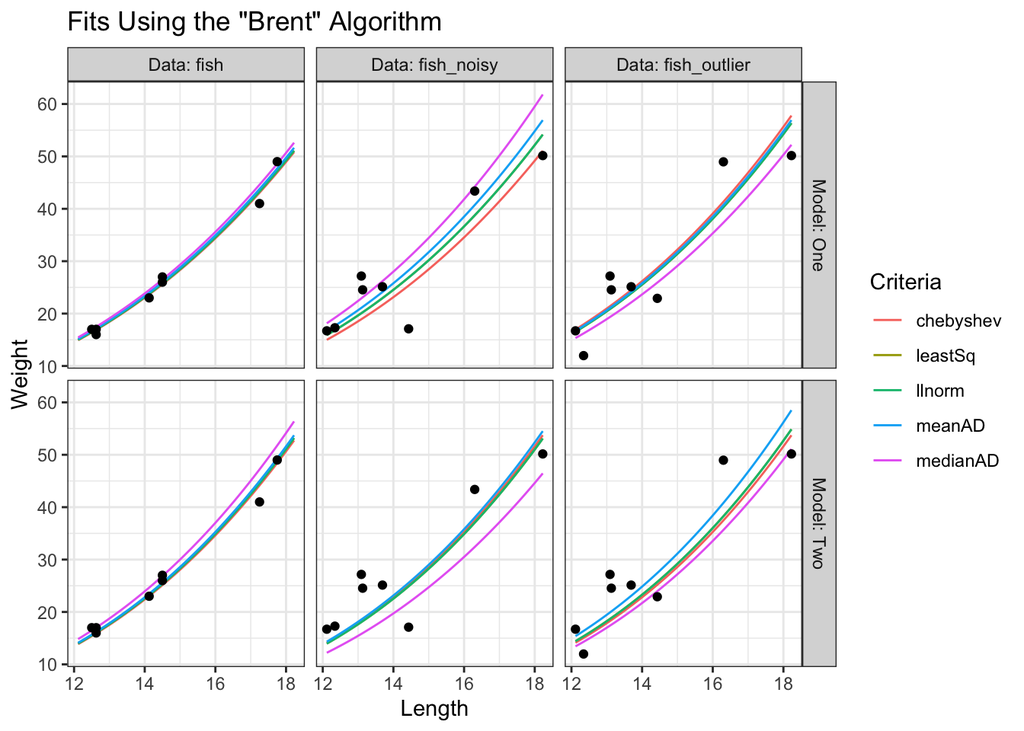

```r
plotData <- data.frame()
for(i in critList){
  for(j in dataList){
    p1 <- subset(results, Data == j & Criteria == i)$par
    p2 <- subset(results2, Data == j & Criteria == i)$par
    plotData <- rbind(plotData,
                      data.frame(l=lVals, Criteria = i, Data = j,
                                 W = c(modelOne(lVals, p1), modelTwo(lVals,gVals,p2)),
                                 Model = rep(c("One","Two"), each = length(lVals)))
                      )
  }
}

g <- ggplot(plotData, aes(x = l, y = W))
g + geom_line(aes(color=Criteria)) + geom_point(data = raw) +
  facet_grid(rows = vars(Model), cols= vars(Data), labeller = label_both) +
  theme_bw() + xlab("Length") + ylab("Weight") + ggtitle("Fits Using the \"Brent\" Algorithm")
```